# Plotting Enzymatic Data

Brady Johnston

27/08/2019

## Plotting enzyme data.

In this example we’re going to be plotting data from multiple enzyme experiments and using some `facet_wrap()` functions to arrange it all nicely.

```r
enzdata <- read.csv("./enzyme.csv")
enzdata
```

```
##    Sub    Exp.1    Exp.2    Exp.3    Exp.4     Exp.5     Exp.6
## 1    0  0.00000  0.00000  0.00000  0.00000  0.000000  0.000000
## 2    1 17.36667 15.70000 27.10667 24.72000  5.723636  2.190476
## 3    2 31.97143 29.42286 42.12000 39.07000 11.480000  5.254545
## 4    4 52.68889 45.64000 63.48000 47.40000 17.697143  8.950000
## 5    8 61.95385 62.60615 69.56000 57.92800 28.813333 15.628571
## 6   12 74.20000 75.78118 74.26857 67.60000 37.567273 20.800000
## 7   16 77.97143 69.88000 79.44444 71.35556 42.483077 25.355556
## 8   20 84.28000 75.25600 83.29091 67.00000 40.680000 26.550000
## 9   30 99.91429 89.59429 87.10000 75.79375 52.810000 32.440000
## 10  40 93.66667 86.84000 82.08571 70.86667 56.920000 33.333333
```

## Melt Data

To make it easier to work with, we need to melt the data into a more workable format.

```r
melt.enz <- melt(enzdata, id.vars = c("Sub"))
head(melt.enz)
```

```
##   Sub variable    value
## 1   0    Exp.1  0.00000
## 2   1    Exp.1 17.36667
## 3   2    Exp.1 31.97143
## 4   4    Exp.1 52.68889
## 5   8    Exp.1 61.95385
## 6  12    Exp.1 74.20000
```

## Start plotting

Here is the fun part where we can start plotting.

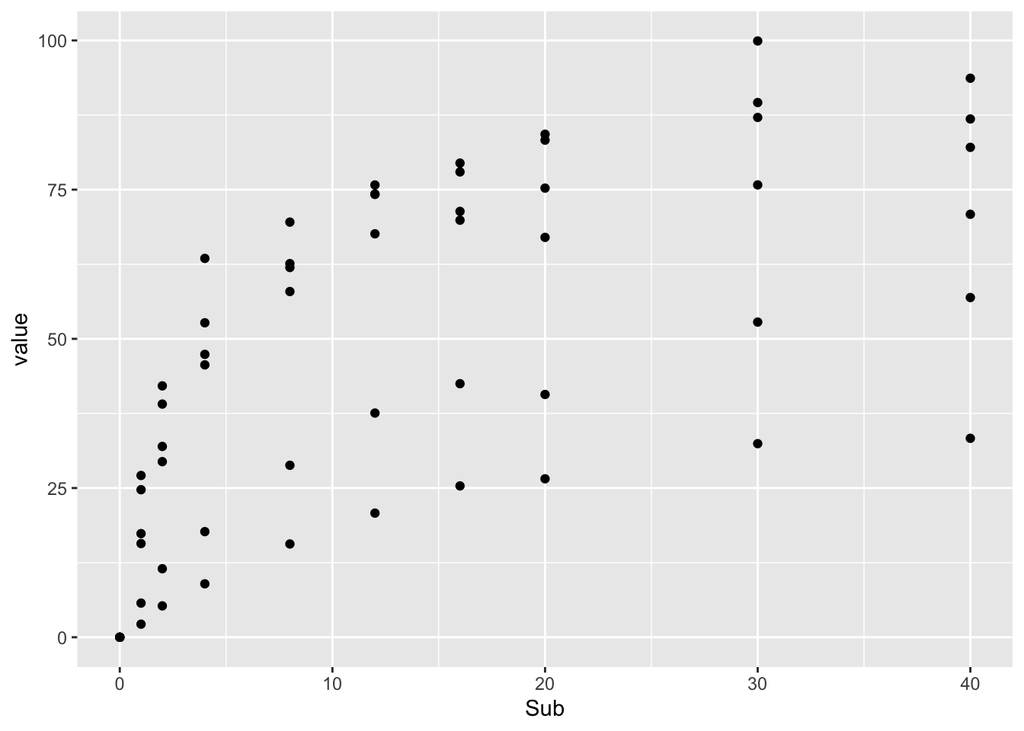

```r
plt <- ggplot(melt.enz, aes(Sub, value)) + geom_point()

plt
```

We can colour-code by adding in `colour=variable` into our `aes()`

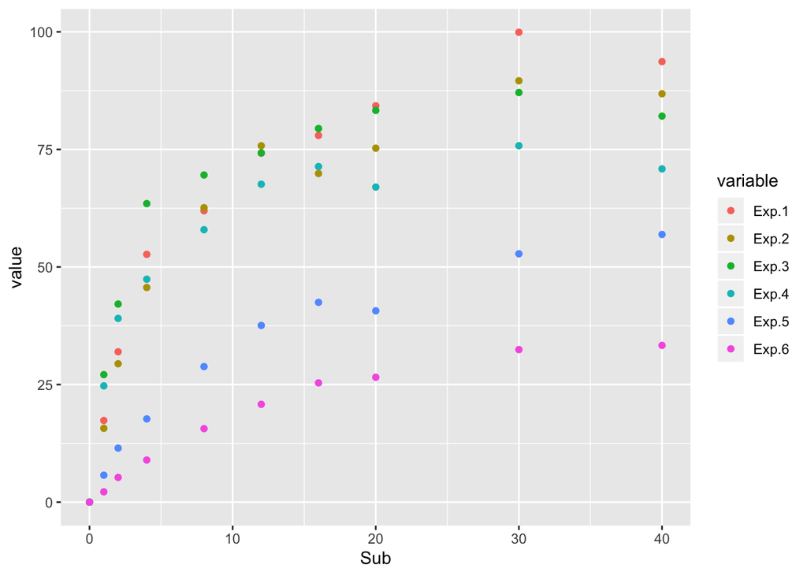

```r
plt <- ggplot(melt.enz, aes(Sub, value, colour=variable)) + geom_point()

plt
```

Time to add some `x` and `y` labels, a title, and make the plot square.

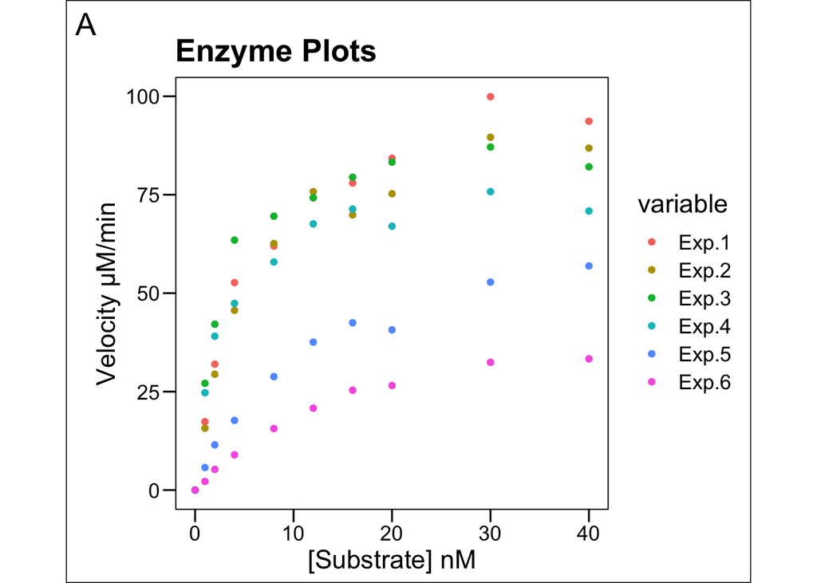

```r
plt <- ggplot(melt.enz, aes(Sub, value, colour=variable)) +
  geom_point() +
  labs(title = "Enzyme Plots") +
  theme_base() +
  theme(aspect.ratio = 1/1) + labs(tag="A") +
  xlab("[Substrate] nM") + ylab("Velocity µM/min")

plt
```

A good way to represent multiple experiments is by having side-by side data. We can do that with the `facet_wrap()` and telling it to separate based on variable.

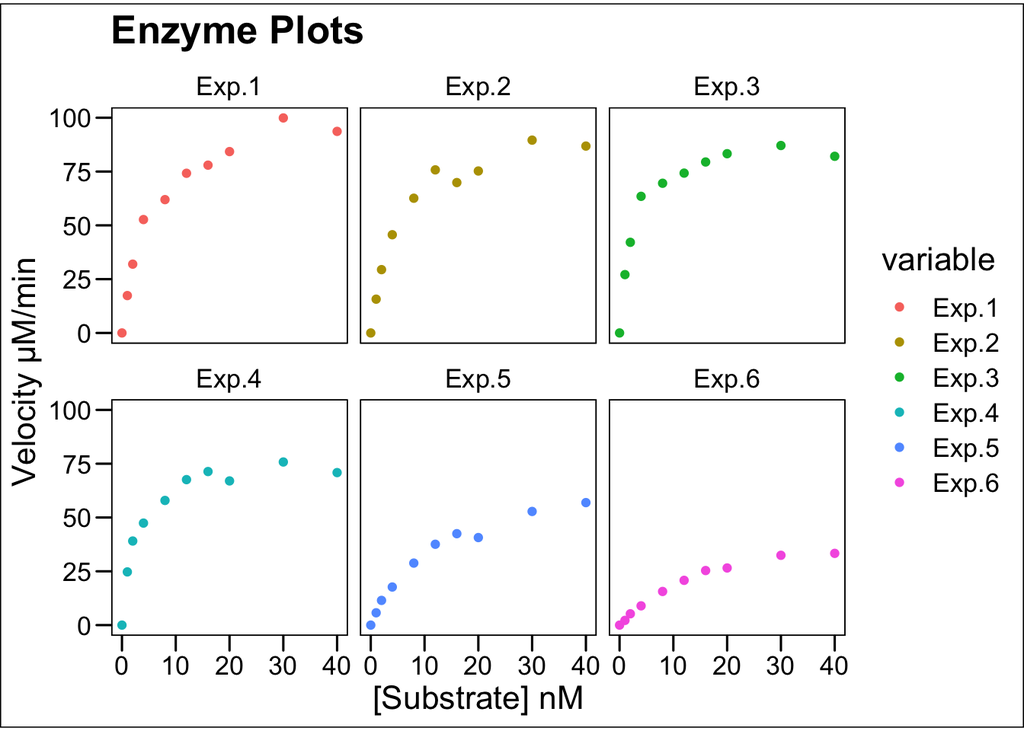

```r
plt <- ggplot(melt.enz, aes(Sub, value, colour=variable)) +
  geom_point() + facet_wrap(~variable) +
  labs(title = "Enzyme Plots") +
  theme_base() +
  theme(aspect.ratio = 1/1) +
  xlab("[Substrate] nM") + ylab("Velocity µM/min")

plt
```

We don’t need the legend anymore, so we can give `legend.position` a `null` variabel that will tell it to not render.

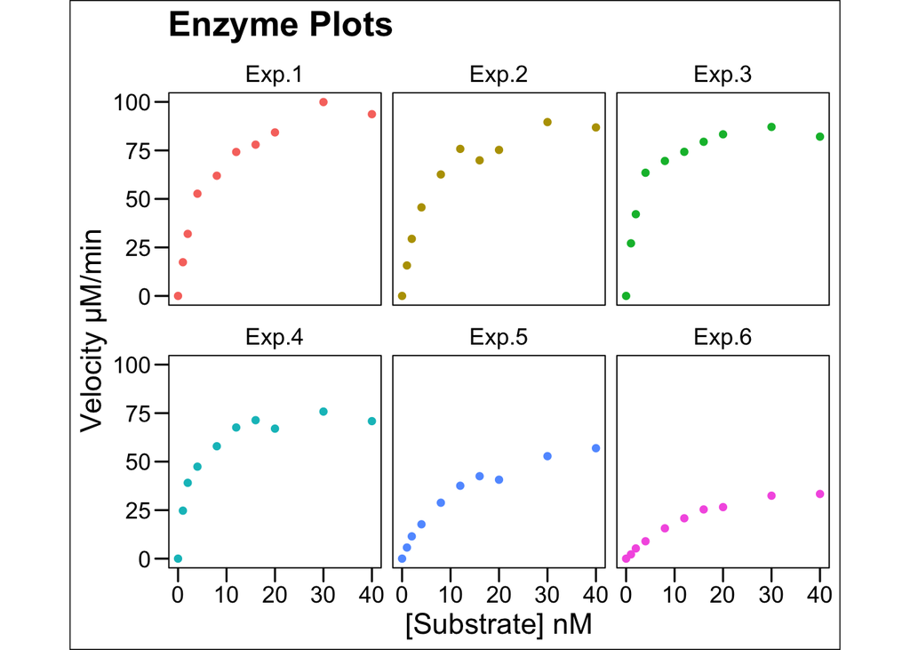

```r
plt <- ggplot(melt.enz, aes(Sub, value, colour=variable)) +
  geom_point() + facet_wrap(~variable) +
  labs(title = "Enzyme Plots") +
  theme_base() +
  theme(aspect.ratio = 1/1, legend.position = "") +
  xlab("[Substrate] nM") + ylab("Velocity µM/min")

plt
```

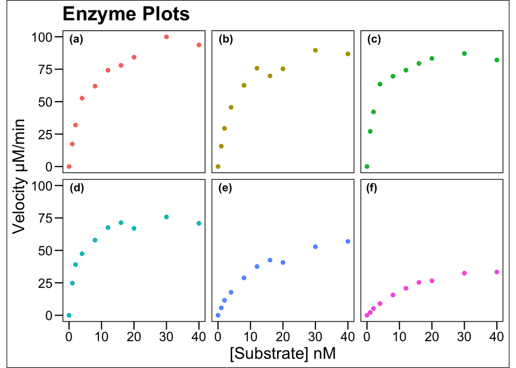

```r
plt <- ggplot(melt.enz, aes(Sub, value, colour=variable)) +
  geom_point() + facet_wrap(~variable) +
  labs(title = "Enzyme Plots") +
  theme_base() +
  theme(aspect.ratio = 1/1, legend.position = "") +
  xlab("[Substrate] nM") + ylab("Velocity µM/min")

tag_facet(plt)
```

I like to have the data in the background so that each plot can be compared to it. To do so, we’ll create a `geom_point()` but with `null` information for what it is being faceted on.

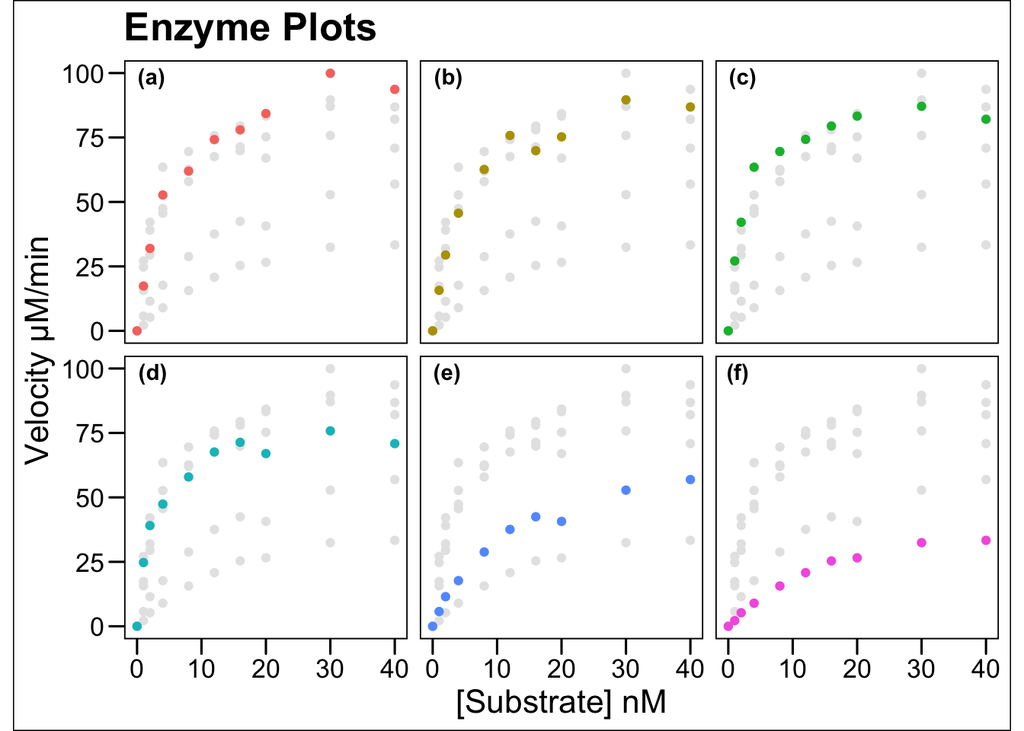

```r
plt <- ggplot(melt.enz, aes(Sub, value, colour=variable)) +
  geom_point(data = transform(melt.enz, variable = NULL), colour = "grey90") +
  geom_point() + facet_wrap(~variable) +
  labs(title = "Enzyme Plots") +
  theme_base() +
  theme(aspect.ratio = 1/1, legend.position = "") +
  xlab("[Substrate] nM") + ylab("Velocity µM/min")

tag_facet(plt)
```

Finally, to add a line to these graphs we can use a function using the Michaelis-Menton equation for plotting the velocity.

### Michaelis-Menton Function

```
enzfit <- function(num) {
  geom_smooth(method = "nls",
              method.args = list(formula = y ~ Vmax * x / (Km + x),
                                 start = list(Vmax = 50, Km = 0.2)),
              se = F, size = 0.5,
              data = subset(melt.enz, variable==paste("Exp.", num, sep = "")), colour = "black")
}
```

### Adding the line to each of the 6 plots.

```
plt + enzfit(1)
head(melt.enz)
for(i in 1:6) {
  assign("plt", plt + enzfit(i), envir = .GlobalEnv)
}
```

### Final code to generate plots from the data.

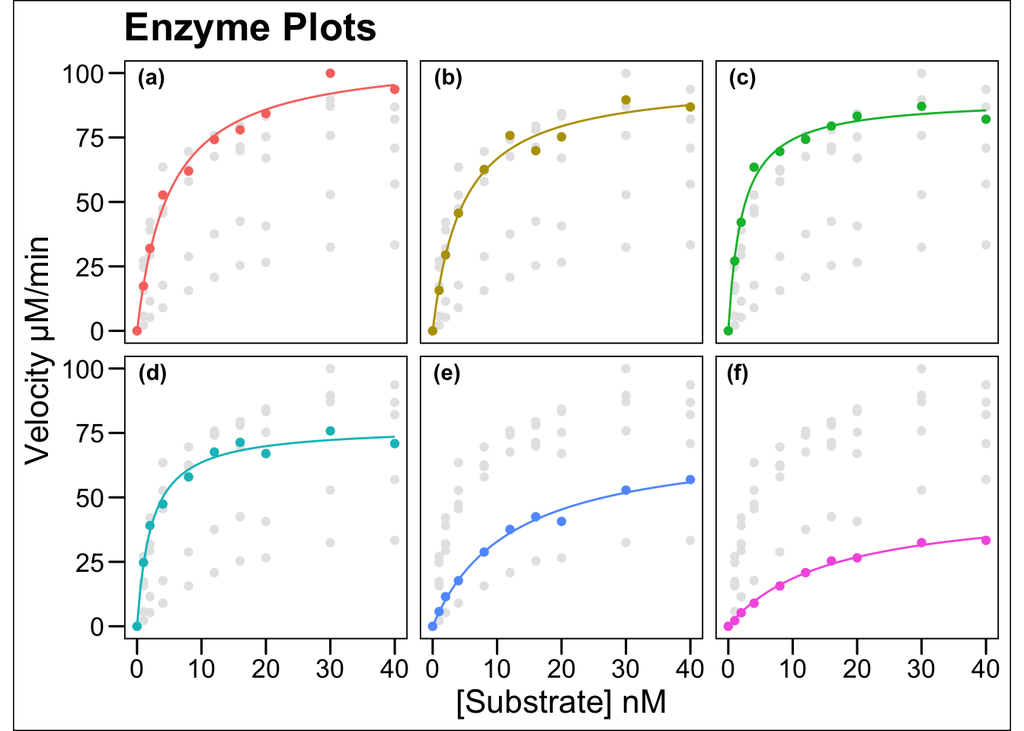

```r
plt <- ggplot(melt.enz, aes(Sub, value, colour=variable)) +
  geom_point(data = transform(melt.enz, variable = NULL), colour = "grey90") +
  geom_point() + facet_wrap(~variable) +
  labs(title = "Enzyme Plots") +
  theme_base() +
  theme(aspect.ratio = 1/1, legend.position = "") +
  xlab("[Substrate] nM") + ylab("Velocity µM/min")

enzfit <- function(num) {
  geom_smooth(method = "nls",
              method.args = list(formula = y ~ Vmax * x / (Km + x),
                                 start = list(Vmax = 50, Km = 0.2)),
              se = F, size = 0.5,
              data = subset(melt.enz, variable==paste("Exp.", num, sep = "")))
}

for(i in 1:6) {
  assign("plt", plt + enzfit(i), envir = .GlobalEnv)
}

tag_facet(plt)
```